# smirnov_hw3

### Алгоритмы интеллектуальной обработки больших объемов данных

## Домашнее задание №3 - Дерево решений

**Общая информация**

**Срок сдачи:** 3 мая 2021, 08:30  
**Штраф за опоздание:** -2 балла после 08:30 03 мая, -4 балла после 08:30 10 мая, -6 баллов после 08:30 17 мая, -8 баллов после 08:30 24 мая.

При отправлении ДЗ указывайте фамилию в названии файла Присылать ДЗ необходимо в виде ссылки на свой github репозиторий на почту ml1.sphere@mail.ru с указанием темы в следующем формате: [ML0221, Задание 3] Фамилия Имя.

Используйте данный Ipython Notebook при оформлении домашнего задания.

## Реализуем дерево решений (3 балла)

Допишите недостающие части дерева решений. Ваша реализация дерева должна работать по точности не хуже DecisionTreeClassifier из sklearn. Внимание: если Вас не устраивает предложенная структура хранения дерева, Вы без потери баллов можете сделать свой класс DecisionTreeClassifier, в котором сами полностью воспроизведете алгоритм дерева решений. Обязательно в нем иметь только функции fit, predict

```python
import matplotlib.pyplot as plt
import numpy as np
import pandas as pd

import sklearn
from sklearn.datasets import load_wine
from sklearn.ensemble import RandomForestClassifier
from sklearn.metrics import accuracy_score, f1_score, roc_auc_score
from sklearn.model_selection import KFold, train_test_split, GridSearchCV, RandomizedSearchCV
from sklearn.tree import DecisionTreeClassifier
from time import time
from contextlib import contextmanager
from collections import defaultdict
```

```python
class MyDecisionTreeClassifier:
    NON_LEAF_TYPE = 0
    LEAF_TYPE = 1

    def __init__(self, min_samples_split=2, max_depth=None, criterion='gini'):
        """
        criterion -- критерий расщепления. необходимо релизовать три:
        ошибка классификации - 'classification_error',
        индекс Джини - 'gini',
        энтропийный критерий - 'entropy',
        max_depth -- максимальная глубина дерева,
        min_samples_split -- минимальное число объектов в листе, чтобы сделать новый сплит
        """
        self.min_samples_split = min_samples_split
        self.max_depth = max_depth
        self.classes = None
        self.num_class = -1
        # Для последнего задания
        self.impurities = defaultdict(int)
        self.feature_importances_ = defaultdict(int)
        self.criterion = criterion
        # Структура, которая описывает дерево
        # Представляет словарь, где для  node_id (айдишник узла дерева) храним
        # (тип_узла, айдишник признака сплита, порог сплита) если тип NON_LEAF_TYPE
        # (тип_узла, предсказание класса, вероятность класса) если тип LEAF_TYPE
        # Подразумевается, что у каждого node_id в дереве слева
        # узел с айди 2 * node_id + 1, а справа 2 * node_id + 2
        self.tree = dict()

    def __div_samples(self, x, y, feature_id, threshold):
        """
        Разделяет объекты на 2 множества
        x -- матрица объектов
        y -- вектор ответов
        feature_id -- айдишник признака, по которому делаем сплит
        threshold -- порог, по которому делаем сплит
        """
        left_mask = x[:, feature_id] > threshold
        right_mask = ~left_mask
        return x[left_mask], x[right_mask], y[left_mask], y[right_mask]


    def __find_threshold(self, x, y):
        """
        Находим оптимальный признак и порог для сплита
        Здесь используемые разные impurity в зависимости от self.criterion
        x -- вектор-признак
        y -- целевая переменная
        """
        indexes_sort = x.argsort()
        sorted_x, sorted_y = x[indexes_sort], y[indexes_sort]
        # Находим индексы, в которых значение признака меняется
        feature_borders = np.where(sorted_x[:-1] != sorted_x[1:])[0] + 1
        # Если значения признака не меняются нигде, то он бесполезен
        if not feature_borders.size:
            return None, -np.inf, None, None
        # Cтроим матрицу one-hot кодирования целевой переменной
        # (как для обычной категориальной переменной) для каждого объекта выборки
        one_hot = np.zeros((y.size, self.num_class))
        one_hot[np.arange(sorted_y.size), sorted_y] = 1
        # Получаем матрицу долей классов при увеличении значения признака
        all_counts = np.cumsum(one_hot, axis = 0)
        # Доли классов для левого и правого листов в индексах, в которых значение признака меняется
        l_counts = all_counts[feature_borders - 1]
        r_counts = all_counts[-1] - l_counts
        # Количество элементов всего в левом и правом листе в тех же индексах
        l_num = feature_borders
        r_num = y.size - feature_borders
        # Считаем критерий информативности для каждого уникального порога
        # Пояснение корректности такого упрощения представлено ниже
        if self.criterion == 'gini':
            left = np.sum(l_counts ** 2, axis = 1) / l_num
            right = np.sum(r_counts ** 2, axis = 1) / r_num
        elif self.criterion == 'entropy':
            l_probas = l_counts / l_num.reshape(-1, 1)
            r_probas = r_counts / r_num.reshape(-1, 1)
            left = np.sum(l_probas * np.log(l_probas, where = l_probas != 0), axis = 1) * l_num
            right = np.sum(r_probas * np.log(r_probas, where = r_probas != 0), axis = 1) * r_num
        elif self.criterion == 'classification_error':
            left = np.max(l_counts, axis = 1)
            right = np.max(r_counts, axis = 1)
        else:
            raise Exception("Invalid criteria")
        scores = left + right
        idx = np.argmax(scores)
        F_l = left[idx]
        F_r = right[idx]
        thr_idx = feature_borders[idx]
        threshold = (sorted_x[thr_idx - 1] + sorted_x[thr_idx]) / 2.0
        return threshold, scores[idx], F_l, F_r


    def __fit_node(self, x, y, node_id, depth):
        """
        Делаем новый узел в дереве
        Решаем, терминальный он или нет
        Если нет, то строим левый узел  с айди 2 * node_id + 1
        И правый узел с  айди 2 * node_id + 2
        """
        # Если остался единственный класс, не продолжаем разбиение
        if np.unique(y).size == 1:
            split = False
        # Проверяем, что в узле достаточно объектов для разбиения
        elif y.size >= self.min_samples_split:
            if self.max_depth is not None:
                # Если указана максимальная глубина, проверяем, что она еще не достигнута
                split = depth < self.max_depth
            else:
                split = True
        else:
            split = False

        if split:
            # Находим максимальный критерий информативности для каждого признака
            scores = np.asarray([self.__find_threshold(x_i, y) for x_i in x.T])
            idx = scores[:, 1].argmax()
            feature_id = idx
            threshold = scores[idx][0]
            F_l = scores[idx][2]
            F_r = scores[idx][3]
            x_left, x_right, y_left, y_right = self.__div_samples(x, y, feature_id, threshold)

            # Вычисление gain
            add = self.criterion != 'entropy'
            if node_id:
                F_curr = self.impurities[(node_id - 1) // 2][1 - node_id % 2]
            else:
                F_curr = 1
            Q = scores[idx][1] / y.size - add + F_curr
            self.feature_importances_[feature_id] += Q
            self.impurities[node_id] = np.array([add - F_l / y_left.size, add - F_r / y_right.size])

            self.tree[node_id] = (self.__class__.NON_LEAF_TYPE, feature_id, threshold)
            self.__fit_node(x_left, y_left, 2 * node_id + 1, depth + 1)
            self.__fit_node(x_right, y_right, 2 * node_id + 2, depth + 1)
        else:
            bins = np.bincount(y)
            self.tree[node_id] = (self.__class__.LEAF_TYPE, bins.argmax(), bins.max() / bins.sum())

    def fit(self, x, y):
        """
        Рекурсивно строим дерево решений
        Начинаем с корня node_id 0
        """
        #считаем, что классы нумеруются с 0 и без пропусков
        self.num_class = np.unique(y).size
        self.feature_importances_ = np.zeros(x.shape[1])
        self.__fit_node(x, y, 0, 0)

    def __predict_class(self, x, node_id):
        """
        Рекурсивно обходим дерево по всем узлам,
        пока не дойдем до терминального
        """
        node = self.tree[node_id]
        if node[0] == self.__class__.NON_LEAF_TYPE:
            _, feature_id, threshold = node
            if x[feature_id] > threshold:
                return self.__predict_class(x, 2 * node_id + 1)
            else:
                return self.__predict_class(x, 2 * node_id + 2)
        else:
            return node[1]

    def predict(self, X):
        """
        Вызывает predict для всех объектов из матрицы X
        """
        return np.array([self.__predict_class(x, 0) for x in X])

    def fit_predict(self, x_train, y_train, predicted_x):
        self.fit(x_train, y_train)
        return self.predict(predicted_x)

    def get_feature_importance(self):
        """
        Возвращает важность признаков
        """
        return self.feature_importances_
```

### Упрощение задачи оптимизации

На каждом шаге построения дерева необходимо разбить все объекты, находящиеся в данном узле, по какому-то признаку так, чтобы максимизировать критерий информативности:

$$Q(i, t) = F(R_{curr}) - \frac{n_l}{n} \cdot F(R_{left}) - \frac{n_r}{n} \cdot F(R_{right}) \to \max \limits_{i, t},$$

где:\ $i$ - номер признака,\ $t$ - порог для признака с номером $i$,\ $R_{curr}$ - множество объектов, находящихся в текущем узле,\ $R_{left} = \{x \in R_{curr}:\ x[i] <= t\}$,\ $R_{right} = \{x \in R_{curr}:\ x[i] > t\}$,\ $n = |R_{curr}|$,\ $n_l = |R_{left}|$,\ $n_r = |R_{right}|$,\ $F$ - функция для вычисления т.н. *impurity*: индекс Джини, энтропийный критерий или ошибка классификации.

Заметим, что $F(R_{curr})$, а, следовательно, и $n$ не зависят от $i$ и $t$, значит, задача максимизации может быть заменена задачей минимизации: $$Q'(i, t) = n_l \cdot F(R_{left}) + n_r \cdot F(R_{right}) \to \min \limits_{i, t}.$$

Рассмотрим теперь данную задачу для конкретных функций $F$.

**Индекс Джини**: $$F(R) = 1 - \sum \limits_{k} p_{R, k}^2,$$\ где $p_{R, k} = \frac{|\{x \in R:\ x_{target} = k\}|}{|R|}$ - доля класса $k$ в данном узле. $$Q'(i, t) = n_l \cdot F(R_{left}) + n_r \cdot F(R_{right}) = $$ $$ = n_l \cdot (1 - \frac{|\{x \in R_{left}:\ x_{target} = k\}|^2}{n_l^2}) + n_r \cdot (1 - \frac{|\{x \in R_{right}:\ x_{target} = k\}|^2}{n_r^2}) = $$ $$ = n_l - \frac{|\{x \in R_{left}:\ x_{target} = k\}|^2}{n_l} + n_r - \frac{|\{x \in R_{right}:\ x_{target} = k\}|^2}{n_r}) = \{n_l + n_r = n\} = $$ $$ = n - \frac{|\{x \in R_{left}:\ x_{target} = k\}|^2}{n_l} - \frac{|\{x \in R_{right}:\ x_{target} = k\}|^2}{n_r} \to \min \limits_{i, t}.$$ Аналогично, $n$ не зависит от $i$ и $t$, поэтому заменяем задачу минимзации на задачу максимизации: $$Q''(i, t) = \frac{|\{x \in R_{left}:\ x_{target} = k\}|^2}{n_l} + \frac{|\{x \in R_{right}:\ x_{target} = k\}|^2}{n_r} \to \max \limits_{i, t}.$$ Связь $Q$ и $Q'$: $$Q = F(R_{curr}) - (\frac{n - Q''}{n}) = \frac{Q''}{n} - 1 + F(R_{curr}).$$

**Энтропийный критерий**: $$F(R) = - \sum \limits_{k} p_{R, k} \cdot log(p_{R, k}).$$ $$Q'(i, t) = n_l \cdot F(R_{left}) + n_r \cdot F(R_{right}) = $$ $$ = n_l \cdot (-\sum \limits_{k} p_{R_{left}, k} \cdot log(p_{R_{left}, k})) + n_r \cdot (-\sum \limits_{k} p_{R_{right}, k} \cdot log(p_{R_{right}, k})) = $$ $$ = - n_l \cdot \sum \limits_{k} p_{R_{left}, k} \cdot log(p_{R_{left}, k}) - n_r \cdot \sum \limits_{k} p_{R_{right}, k} \cdot log(p_{R_{right}, k}).$$ Заменяем задачу минимзации на задачу максимизации: $$Q''(i, t) = n_l \cdot \sum \limits_{k} p_{R_{left}, k} \cdot log(p_{R_{left}, k}) + n_r \cdot \sum \limits_{k} p_{R_{right}, k} \cdot log(p_{R_{right}, k}) \to \max \limits_{i, t}.$$ Связь $Q$ и $Q'$: $$Q = F(R_{curr}) + \frac{Q''}{n}.$$

**Ошибка классификации**: $$F(R) = 1 - \max \limits_{k} p_{R, k} = 1 - \max \limits_{k} \frac{|\{x \in R:\ x_{target} = k\}|}{|R|}.$$ $$Q'(i, t) = n_l \cdot F(R_{left}) + n_r \cdot F(R_{right}) = $$ $$ = n_l \cdot (1 - \max \limits_{k} \frac{|\{x \in R_{left}:\ x_{target} = k\}|}{n_l}) + n_r \cdot (1 - \max \limits_{k} \frac{|\{x \in R_{right}:\ x_{target} = k\}|}{n_r}) = $$ $$ = n_l - n_l \cdot \max \limits_{k} \frac{|\{x \in R_{left}:\ x_{target} = k\}|}{n_l}) + n_r - n_r \cdot \max \limits_{k} \frac{|\{x \in R_{right}:\ x_{target} = k\}|}{n_r}) = \{n_l + n_r = n\} = $$ $$ = n - \max \limits_{k} |\{x \in R_{left}:\ x_{target} = k\}| - \max \limits_{k} |\{x \in R_{right}:\ x_{target} = k\}|.$$ Аналогично, $n$ не зависит от $i$ и $t$, поэтому заменяем задачу минимзации на задачу максимизации: $$Q''(i, t) = \max \limits_{k} |\{x \in R_{left}:\ x_{target} = k\}| + \max \limits_{k} |\{x \in R_{right}:\ x_{target} = k\}| \to \max \limits_{i, t}.$$ Связь $Q$ и $Q'$: $$Q = F(R_{curr}) - (\frac{n - Q''}{n}) = \frac{Q''}{n} - 1 + F(R_{curr}).$$

```python
my_clf = MyDecisionTreeClassifier(criterion = 'gini', min_samples_split=2)
clf = DecisionTreeClassifier(criterion = 'gini', min_samples_split=2)
```

```python
wine = load_wine()
X_train, X_test, y_train, y_test = train_test_split(wine.data, wine.target, test_size=0.1, stratify=wine.target)
```

```python
clf.fit(X_train, y_train)
my_clf.fit(X_train, y_train)
```

```python
accuracy_score(y_pred=clf.predict(X_test), y_true=y_test)
```

```
0.9444444444444444
```

```python
accuracy_score(y_pred=my_clf.predict(X_test), y_true=y_test)
```

```
0.9444444444444444
```

## Ускоряем дерево решений (2 балла)

Добиться скорости работы на fit не медленнее чем в 10 раз sklearn на данных wine. Для этого используем numpy.

```python
%time clf.fit(X_train, y_train)
```

```
CPU times: user 3.07 ms, sys: 63 µs, total: 3.13 ms
Wall time: 2.02 ms
```

```
DecisionTreeClassifier()
```

```python
%time my_clf.fit(X_train, y_train)
```

```
CPU times: user 12.5 ms, sys: 9 µs, total: 12.6 ms
Wall time: 11.8 ms
```

## Боевое применение (3 балла)

На практике Вы познакомились с датасетом Speed Dating Data. В нем каждая пара в быстрых свиданиях характеризуется определенным набором признаков. Задача -- предсказать, произойдет ли матч пары (колонка match).

Пример работы с датасетом можете найти в практике пункт 2 https://github.com/VVVikulin/ml1.sphere/blob/master/2019-09/lecture_06/pract-trees.ipynb

Данные и описания колонок лежат тут https://cloud.mail.ru/public/8nHV/p6J7wY1y1/speed-dating-experiment/

Скачайте датасет, обработайте данные, как показано на семинаре или своим собственным способом. Обучите дерево классифкации. В качестве таргета возьмите колонку 'match'. Постарайтесь хорошо обработать признаки, чтобы выбить максимальную точность. Если точность будет близка к случайному гаданию, задание не будет защитано.

### Загрузка данных

```python
df = pd.read_csv('./data/Speed Dating Data.csv', encoding='latin1')
```

```python
df.shape
```

```
(8378, 195)
```

```python
df.head(5)
```

|  | iid | id | gender | idg | condtn | wave | round | position | positin1 | order | ... | attr3_3 | sinc3_3 | intel3_3 | fun3_3 | amb3_3 | attr5_3 | sinc5_3 | intel5_3 | fun5_3 | amb5_3 |
| --- | --- | --- | --- | --- | --- | --- | --- | --- | --- | --- | --- | --- | --- | --- | --- | --- | --- | --- | --- | --- | --- |
| 0 | 1 | 1.0 | 0 | 1 | 1 | 1 | 10 | 7 | NaN | 4 | ... | 5.0 | 7.0 | 7.0 | 7.0 | 7.0 | NaN | NaN | NaN | NaN | NaN |
| 1 | 1 | 1.0 | 0 | 1 | 1 | 1 | 10 | 7 | NaN | 3 | ... | 5.0 | 7.0 | 7.0 | 7.0 | 7.0 | NaN | NaN | NaN | NaN | NaN |
| 2 | 1 | 1.0 | 0 | 1 | 1 | 1 | 10 | 7 | NaN | 10 | ... | 5.0 | 7.0 | 7.0 | 7.0 | 7.0 | NaN | NaN | NaN | NaN | NaN |
| 3 | 1 | 1.0 | 0 | 1 | 1 | 1 | 10 | 7 | NaN | 5 | ... | 5.0 | 7.0 | 7.0 | 7.0 | 7.0 | NaN | NaN | NaN | NaN | NaN |
| 4 | 1 | 1.0 | 0 | 1 | 1 | 1 | 10 | 7 | NaN | 7 | ... | 5.0 | 7.0 | 7.0 | 7.0 | 7.0 | NaN | NaN | NaN | NaN | NaN |

5 rows × 195 columns

### Подготовка датасета

```python
df = df.iloc[:, :97]
df = df.drop(['id', 'idg', 'condtn', 'round',
              'position', 'positin1', 'partner'], axis=1)
df = df.drop(['age_o', 'race_o', 'pf_o_att',
              'pf_o_sin', 'pf_o_int',
              'pf_o_fun', 'pf_o_amb', 'pf_o_sha',
              'dec_o', 'attr_o', 'sinc_o', 'intel_o', 'fun_o',
              'amb_o', 'shar_o', 'like_o', 'prob_o','met_o'] , axis=1)

df = df.drop(['from', 'zipcode'], axis=1)

df = df.dropna(subset=['age'])

df.loc[:, 'field_cd'] = df.loc[:, 'field_cd'].fillna(19)
df = df.drop(['field'], axis=1)

df = df.drop(['undergra'], axis=1)

df.loc[:, 'mn_sat'] = df.loc[:, 'mn_sat'].str.replace(',', '').astype(np.float)
df.loc[:, 'mn_sat'] = df.loc[:, 'mn_sat'].fillna(df.mn_sat.mean())

df.loc[:, 'tuition'] = df.loc[:, 'tuition'].str.replace(',', '').astype(np.float)
df.loc[:, 'tuition'] = df.loc[:, 'tuition'].fillna(df.tuition.mean())

df = df.dropna(subset=['imprelig', 'imprace'])

df.loc[:, 'income'] = df.loc[:, 'income'].str.replace(',', '').astype(np.float)
df.loc[:, 'income'] = df.loc[:, 'income'].fillna(df.income.mean())

df = df.dropna(subset=['date'])

df.loc[:, 'career_c'] = df.loc[:, 'career_c'].fillna(18)
df = df.drop(['career'], axis=1)

df = df.drop(['sports', 'tvsports', 'exercise', 'dining', 'museums',
              'art', 'hiking', 'gaming', 'clubbing', 'reading', 'tv',
              'theater', 'movies', 'concerts', 'music', 'shopping', 'yoga'], axis=1)

df = df.drop(['expnum'], axis=1)

df.loc[:, 'temp_totalsum'] = \
    df.loc[:, ['attr1_1', 'sinc1_1', 'intel1_1', 'fun1_1', 'amb1_1', 'shar1_1']].sum(axis=1)

df.loc[:, ['attr1_1', 'sinc1_1', 'intel1_1', 'fun1_1', 'amb1_1', 'shar1_1']] = \
    (df.loc[:, ['attr1_1', 'sinc1_1', 'intel1_1', 'fun1_1', 'amb1_1', 'shar1_1']].T /
     df.loc[:, 'temp_totalsum'].T).T * 100

df.loc[:, 'temp_totalsum'] = \
    df.loc[:, ['attr2_1', 'sinc2_1', 'intel2_1', 'fun2_1', 'amb2_1', 'shar2_1']].sum(axis=1)
df.loc[:, ['attr2_1', 'sinc2_1', 'intel2_1', 'fun2_1', 'amb2_1', 'shar2_1']] = \
    (df.loc[:, ['attr2_1', 'sinc2_1', 'intel2_1', 'fun2_1', 'amb2_1', 'shar2_1']].T /
     df.loc[:, 'temp_totalsum'].T).T * 100

df = df.drop(['temp_totalsum'], axis=1)

for i in [4, 5]:
    feat = ['attr{}_1'.format(i), 'sinc{}_1'.format(i),
            'intel{}_1'.format(i), 'fun{}_1'.format(i),
            'amb{}_1'.format(i), 'shar{}_1'.format(i)]

    if i != 4:
        feat.remove('shar{}_1'.format(i))

    df = df.drop(feat, axis=1)

df = df.drop(['wave'], axis=1)

df_male = df.query('gender == 1').drop_duplicates(subset=['iid', 'pid'])\
                                 .drop(['gender'], axis=1)\
                                 .dropna()
df_female = df.query('gender == 0').drop_duplicates(subset=['iid'])\
                                   .drop(['gender', 'match', 'int_corr', 'samerace'], axis=1)\
                                   .dropna()
df_female.columns = df_female.columns + '_f'

df_final = df_male.join(df_female.set_index('iid_f'), on='pid', how='inner')
df_final = df_final.drop(['iid', 'pid', 'pid_f'], axis=1)

X = df_final.loc[:, df_final.columns != 'match'].to_numpy()
y = df_final.match.to_numpy()
```

Разбейте датасет на трейн и валидацию. Подберите на валидации оптимальный критерий информативности. Постройте графики зависимости точности на валидации от глубины дерева, от минимального числа объектов для сплита. Какой максимальной точности удалось достигнуть?

```python
X_train, X_test, y_train, y_test = train_test_split(X, y, test_size = 0.1)
```

```python
my_clf = MyDecisionTreeClassifier(min_samples_split=2, criterion='gini')
clf = DecisionTreeClassifier(min_samples_split=2, criterion='gini')
```

```python
my_clf.fit(X_train, y_train)
clf.fit(X_train, y_train)
```

```
DecisionTreeClassifier()
```

```python
accuracy_score(y_pred=clf.predict(X_test), y_true=y_test)
```

```
0.7375
```

```python
accuracy_score(y_pred=my_clf.predict(X_test), y_true=y_test)
```

```
0.74
```

```python
hyperparameters = pd.DataFrame(columns=["Criterion", "max_depth", "min_samples_split", "accuracy"])
```

```python
criterions = ['gini', 'entropy', 'classification_error']
max_depths = range(1, 21, 1)
min_samples_splits = range(2, 21, 1)
```

```python
i = 0
for criterion in criterions:
    for max_depth in max_depths:
        for min_samples_split in min_samples_splits:
            clf = MyDecisionTreeClassifier(
                criterion=criterion,
                max_depth=max_depth,
                min_samples_split=min_samples_split)
            clf.fit(X_train, y_train)
            acc = accuracy_score(y_pred=clf.predict(X_test), y_true=y_test)
            hyperparameters = hyperparameters.append({
                "Criterion": criterion,
                "max_depth": max_depth,
                "min_samples_split": min_samples_split,
                "accuracy": acc
            }, ignore_index=True)
            print(hyperparameters.loc[[i]])
            i += 1
```

```
  Criterion max_depth min_samples_split  accuracy
0      gini         1                 2    0.8375
  Criterion max_depth min_samples_split  accuracy
1      gini         1                 3    0.8375
  Criterion max_depth min_samples_split  accuracy
2      gini         1                 4    0.8375
  Criterion max_depth min_samples_split  accuracy
3      gini         1                 5    0.8375
  Criterion max_depth min_samples_split  accuracy
4      gini         1                 6    0.8375
  Criterion max_depth min_samples_split  accuracy
5      gini         1                 7    0.8375
  Criterion max_depth min_samples_split  accuracy
6      gini         1                 8    0.8375
  Criterion max_depth min_samples_split  accuracy
7      gini         1                 9    0.8375
  Criterion max_depth min_samples_split  accuracy
8      gini         1                10    0.8375
  Criterion max_depth min_samples_split  accuracy
9      gini         1                11    0.8375
   Criterion max_depth min_samples_split  accuracy
10      gini         1                12    0.8375
   Criterion max_depth min_samples_split  accuracy
11      gini         1                13    0.8375
   Criterion max_depth min_samples_split  accuracy
12      gini         1                14    0.8375
   Criterion max_depth min_samples_split  accuracy
13      gini         1                15    0.8375
   Criterion max_depth min_samples_split  accuracy
14      gini         1                16    0.8375
   Criterion max_depth min_samples_split  accuracy
15      gini         1                17    0.8375
   Criterion max_depth min_samples_split  accuracy
16      gini         1                18    0.8375
   Criterion max_depth min_samples_split  accuracy
17      gini         1                19    0.8375
   Criterion max_depth min_samples_split  accuracy
18      gini         1                20    0.8375
   Criterion max_depth min_samples_split  accuracy
19      gini         2                 2    0.8375
```

[output cut: 2225 more lines]

```
1132  classification_error        20                13    0.7975
                 Criterion max_depth min_samples_split  accuracy
1133  classification_error        20                14     0.795
                 Criterion max_depth min_samples_split  accuracy
1134  classification_error        20                15     0.795
                 Criterion max_depth min_samples_split  accuracy
1135  classification_error        20                16     0.795
                 Criterion max_depth min_samples_split  accuracy
1136  classification_error        20                17     0.795
                 Criterion max_depth min_samples_split  accuracy
1137  classification_error        20                18     0.795
                 Criterion max_depth min_samples_split  accuracy
1138  classification_error        20                19     0.795
                 Criterion max_depth min_samples_split  accuracy
1139  classification_error        20                20     0.795
```

```python
hyperparameters.to_csv("hyperparameters.csv", index=False)
```

```python
hyperparameters = pd.read_csv("hyperparameters.csv")
hyperparameters.head(10)
```

|  | Criterion | max_depth | min_samples_split | accuracy |
| --- | --- | --- | --- | --- |
| 0 | gini | 1 | 2 | 0.8375 |
| 1 | gini | 1 | 3 | 0.8375 |
| 2 | gini | 1 | 4 | 0.8375 |
| 3 | gini | 1 | 5 | 0.8375 |
| 4 | gini | 1 | 6 | 0.8375 |
| 5 | gini | 1 | 7 | 0.8375 |
| 6 | gini | 1 | 8 | 0.8375 |
| 7 | gini | 1 | 9 | 0.8375 |
| 8 | gini | 1 | 10 | 0.8375 |
| 9 | gini | 1 | 11 | 0.8375 |

```python
hyperparameters[hyperparameters.accuracy == hyperparameters.accuracy.max()]
```

|  | Criterion | max_depth | min_samples_split | accuracy |
| --- | --- | --- | --- | --- |
| 0 | gini | 1 | 2 | 0.8375 |
| 1 | gini | 1 | 3 | 0.8375 |
| 2 | gini | 1 | 4 | 0.8375 |
| 3 | gini | 1 | 5 | 0.8375 |
| 4 | gini | 1 | 6 | 0.8375 |
| ... | ... | ... | ... | ... |
| 793 | classification_error | 2 | 16 | 0.8375 |
| 794 | classification_error | 2 | 17 | 0.8375 |
| 795 | classification_error | 2 | 18 | 0.8375 |
| 796 | classification_error | 2 | 19 | 0.8375 |
| 797 | classification_error | 2 | 20 | 0.8375 |

138 rows × 4 columns

```python
hyperparameters[hyperparameters.accuracy == hyperparameters.accuracy.max()].Criterion.unique()
```

```
array(['gini', 'entropy', 'classification_error'], dtype=object)
```

```python
%matplotlib inline
plt.style.use('ggplot')
plt.rcParams['figure.figsize'] = (12, 5)
```

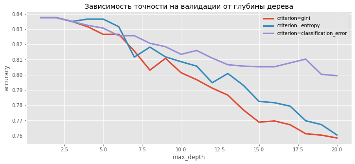

```python
plt.title("Зависимость точности на валидации от глубины дерева")
plt.ylabel("accuracy")
plt.xlabel("max_depth")

for cri in ['gini', 'entropy', 'classification_error']:
    accuracies = hyperparameters[hyperparameters.Criterion == cri]
    accuracies = accuracies.groupby('max_depth').agg({'accuracy': 'mean'})
    depths = list(accuracies.index)
    accuracies = list(accuracies.accuracy)
    plt.plot(depths,
             accuracies,
             label='criterion={}'.format(cri),
             linewidth=3)
plt.legend()
```

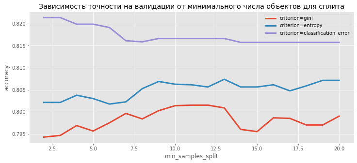

```python
plt.title("Зависимость точности на валидации от минимального числа объектов для сплита")
plt.ylabel("accuracy")
plt.xlabel("min_samples_split")

for cri in ['gini', 'entropy', 'classification_error']:
    accuracies = hyperparameters[hyperparameters.Criterion == cri]
    accuracies = accuracies.groupby('min_samples_split').agg({'accuracy': 'mean'})
    depths = list(accuracies.index)
    accuracies = list(accuracies.accuracy)
    plt.plot(depths,
             accuracies,
             label='criterion={}'.format(cri),
             linewidth=3)
plt.legend()
```

## Находим самые важные признаки (2 балла)

По построенному дереву легко понять, какие признаки лучше всего помогли решить задачу. Часто это бывает нужно не только для сокращения размерности в данных, но и для лучшего понимания прикладной задачи. Например, Вы хотите понять, какие признаки стоит еще конструировать -- для этого нужно понимать, какие из текущих лучше всего работают в дереве.

Самый простой метод -- посчитать число сплитов, где использовался данные признак. Это не лучший вариант, так как по признаку который принимает всего 2 значения, но который почти точно разделяет выборку, число сплитов будет очень 1, но при этом признак сам очень хороший. В этом задании предлагается для каждого признака считать суммарный gain (в лекции обозначено как Q) при использовании этого признака в сплите. Тогда даже у очень хороших признаков с маленьким число сплитов это значение должно быть довольно высоким.

Реализовать это довольно просто: создаете словарь номер фичи : суммарный гейн и добавляете в нужную фичу каждый раз, когда используете ее при построении дерева.

Добавьте функционал, который определяет значения feature importance. Обучите дерево на датасете Speed Dating Data. Выведите 10 главных фичей по важности.

```python
my_clf = MyDecisionTreeClassifier(min_samples_split=2, criterion='gini')
clf = DecisionTreeClassifier(min_samples_split=2, criterion='gini')
```

```python
my_clf.fit(X_train, y_train)
clf.fit(X_train, y_train)
```

```
DecisionTreeClassifier()
```

```python
features = np.array(df_final.loc[:, df_final.columns != 'match'].columns)
```

```python
features[np.argsort(-my_clf.feature_importances_)[:10]]
```

```
array(['int_corr', 'samerace', 'order', 'age', 'field_cd', 'mn_sat',
       'race', 'imprace', 'income', 'goal'], dtype=object)
```

## Фидбек (бесценно)

- Какие аспекты обучения деревьев решений Вам показались непонятными? Какое место стоит дополнительно объяснить?

### Ваш ответ здесь

- Здесь Вы можете оставить отзыв о этой домашней работе или о всем курсе.

### ВАШ ОТЗЫВ ЗДЕСЬ